# Machine Learning - Heirarchical Clustering

SrushtiP

11/10/2019

Problem Statement:

The dataset Cereals.csv includes nutritional information, store display, and consumer ratings for 77 breakfast cereals.

Data Preprocessing. Remove all cereals with missing values

Libraries required throughout the assignment.

```r
library(ISLR)
library(cluster)
library(factoextra)
library(analogue)
library(Rfast)
library(GGally)
```

Reading the data from the dataset and changing the Name column as the row name.

```r
Data <- read.csv("Cereals.csv")

rownames(Data) <- Data$name
Data <- Data[-1]

View(Data)
```

Normalisation of the data is usually performed on the quantitative data. Hence, here we are normalizing the quantitative data and keeping the catagorical variables as it is.

```r
Norm_Data <- scale(Data[c(-1,-2,-12)])
```

Omititng the NA values from the dataset.

```r
Norm_Data <- as.data.frame(na.omit(Norm_Data))
summary(Norm_Data)
```

```
##     calories            protein              fat
##  Min.   :-2.919461   Min.   :-1.41165   Min.   :-1.0065
##  1st Qu.:-0.353268   1st Qu.:-0.49823   1st Qu.:-1.0065
##  Median : 0.159970   Median :-0.04152   Median :-0.0129
##  Mean   : 0.007386   Mean   :-0.02918   Mean   :-0.0129
##  3rd Qu.: 0.159970   3rd Qu.: 0.41519   3rd Qu.:-0.0129
##  Max.   : 2.726163   Max.   : 3.15544   Max.   : 3.9614
##      sodium             fiber               carbo
##  Min.   :-1.90470   Min.   :-0.902904   Min.   :-2.50878
##  1st Qu.:-0.29434   1st Qu.:-0.798010   1st Qu.:-0.71728
##  Median : 0.24244   Median :-0.063754   Median :-0.07745
##  Mean   : 0.03208   Mean   : 0.009956   Mean   :-0.01866
##  3rd Qu.: 0.68977   3rd Qu.: 0.355821   3rd Qu.: 0.56237
##  Max.   : 1.91245   Max.   : 4.971147   Max.   : 2.09795
##      sugars             potass             vitamins
##  Min.   :-1.60467   Min.   :-1.188267   Min.   :-1.26426
##  1st Qu.:-0.91953   1st Qu.:-0.815454   1st Qu.:-0.14532
##  Median :-0.00601   Median :-0.123087   Median :-0.14532
##  Mean   : 0.01868   Mean   :-0.002175   Mean   : 0.03613
##  3rd Qu.: 0.90751   3rd Qu.: 0.302985   3rd Qu.:-0.14532
##  Max.   : 1.82103   Max.   : 3.285488   Max.   : 3.21151
##      weight               cups               rating
##  Min.   :-3.519548   Min.   :-2.453800   Min.   :-1.75286
##  1st Qu.:-0.196777   1st Qu.:-0.649027   1st Qu.:-0.72729
##  Median :-0.196777   Median :-0.305260   Median :-0.17175
##  Mean   : 0.007977   Mean   : 0.002504   Mean   :-0.02092
##  3rd Qu.:-0.196777   3rd Qu.: 0.769010   3rd Qu.: 0.55918
##  Max.   : 3.125994   Max.   : 2.917550   Max.   : 3.63339
```

1. ) Apply hierarchical clustering to the data using Euclidean distance to the normalized measurements. Use Agnes to compare the clustering from single linkage, complete linkage, average linkage, and Ward. Choose the best method.

```r
SL <- agnes(Norm_Data, method = "single")

AL <- agnes(Norm_Data, method = "average")

CL <- agnes(Norm_Data, method = "complete")

WL <- agnes(Norm_Data, method = "ward")

cbind.data.frame(SL$ac, AL$ac, CL$ac, WL$ac)
```

```
##       SL$ac     AL$ac     CL$ac     WL$ac
## 1 0.6091225 0.7888569 0.8508357 0.9088247
```

As we look at the above linkages, we can see that the Agglomerative coefficients of Ward Linkage is highest. Hence we can use the Ward linkage to form the clusters.

We are using the Euclideans Distance to compute the distance and assign elements to each cluster.

```r
Euclidean_dist <- dist(Norm_Data, method = "euclidean")
Dist_Ward <- hclust(Euclidean_dist, method = "ward.D")
```

Plotting the dendrogram of the Ward’s

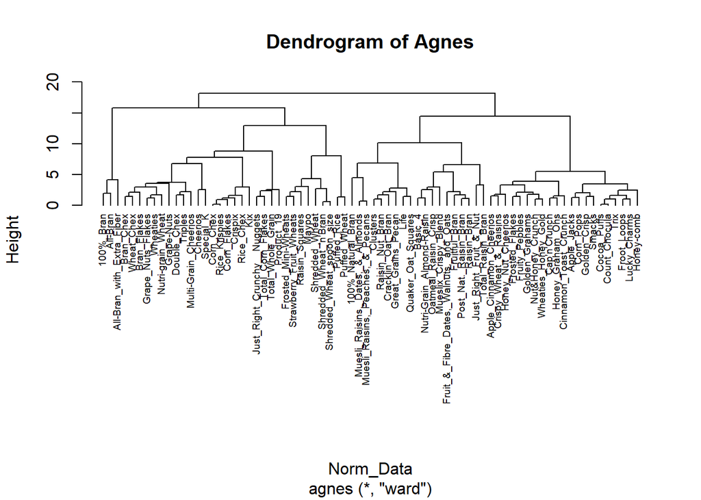

```r
pltree(WL, cex = 0.6, hang = -1, main = "Dendrogram of Agnes")
```

2.) How many clusters would you choose?

Now, we plot the dendrogram and try to find the optimal value for k.

Lets consider K = 2:

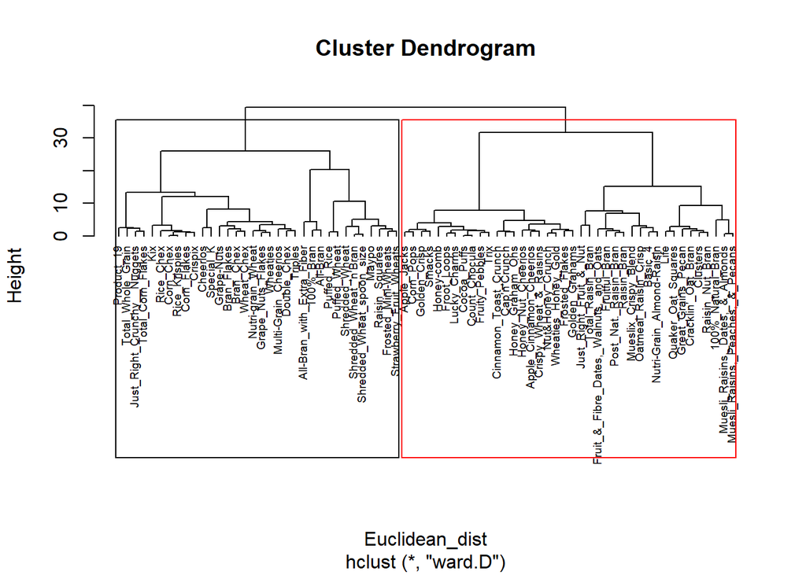

```r
plot(Dist_Ward, cex = 0.6, hang = -1)
rect.hclust(Dist_Ward, k = 2, border = 1:2)
```

Using k = 2, we can see that the content of each cluster is almost same which cannot distinguish any cluster. Thus k = 2 may not be a good choice.

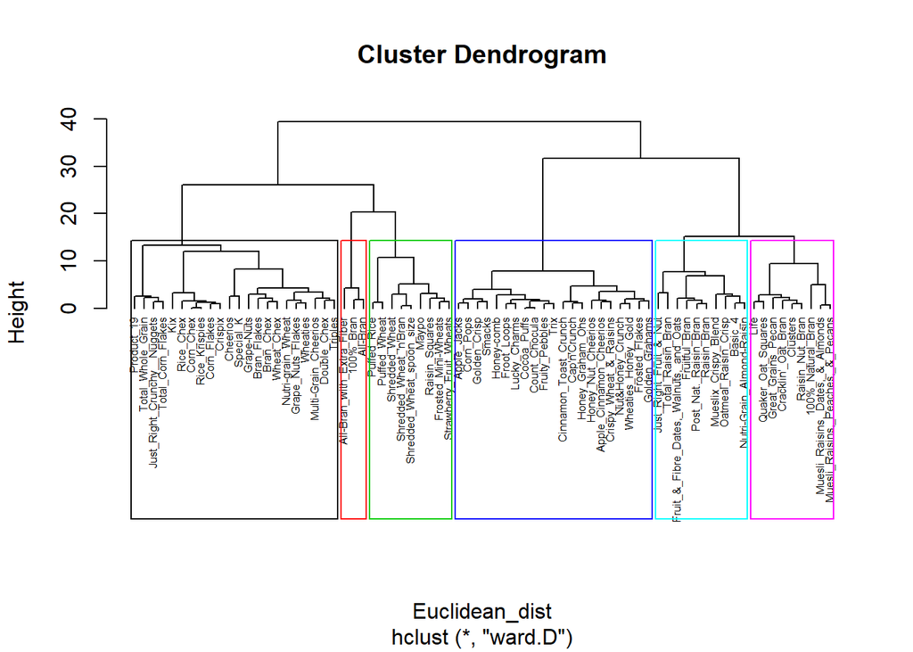

```r
plot(Dist_Ward, cex = 0.5, hang = -1)
rect.hclust(Dist_Ward, k = 6, border = 1:6)
```

Here considering k= 6, we are facing a problem with uneveness of the nutrients content so the cluster formed and not exactly optimal clusters. Thus, k = 6 is also not a good choice.

Now let us consider k = 4:

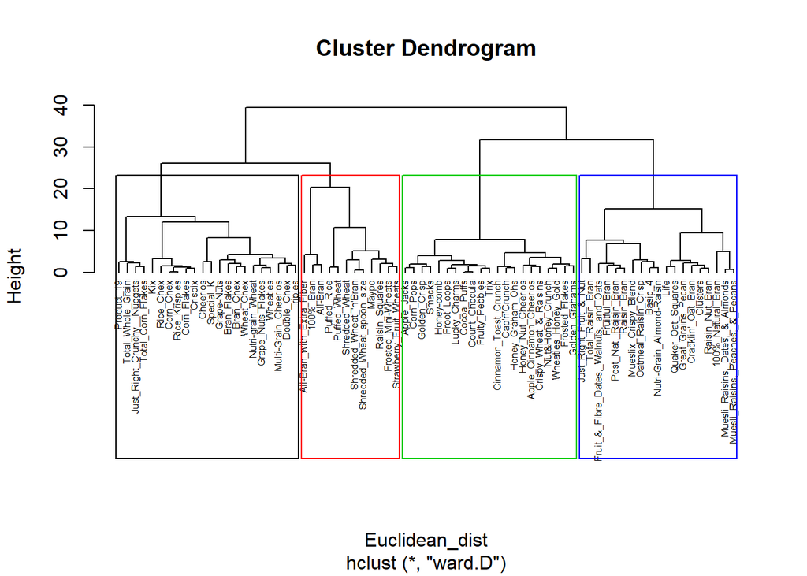

```r
plot(Dist_Ward, cex = 0.5, hang = -1)
rect.hclust(Dist_Ward, k = 4, border = 1:4)
```

```r
Cluster_group <- cutree(Dist_Ward, k = 4)
table(Cluster_group)
```

```
## Cluster_group
##  1  2  3  4
## 12 19 21 22
```

```r
clustered_Data <- cbind.data.frame(Norm_Data, Cluster_group)
```

The table represents the cereals in each clusters.

3.) Comment on the structure of the clusters and on their stability. Hint: To check stability, partition the data and see how well clusters formed based on one part apply to the other part. To do this:

1. Cluster partition A

Here we have partitioned the data in 80 - 20 % format.

```r
Train_Data <- Norm_Data[1:60,]
Test_Data <- Norm_Data[61:74,]
```

2. Use the cluster centroids from A to assign each record in partition B (each record is assigned to the cluster with the closest centroid).

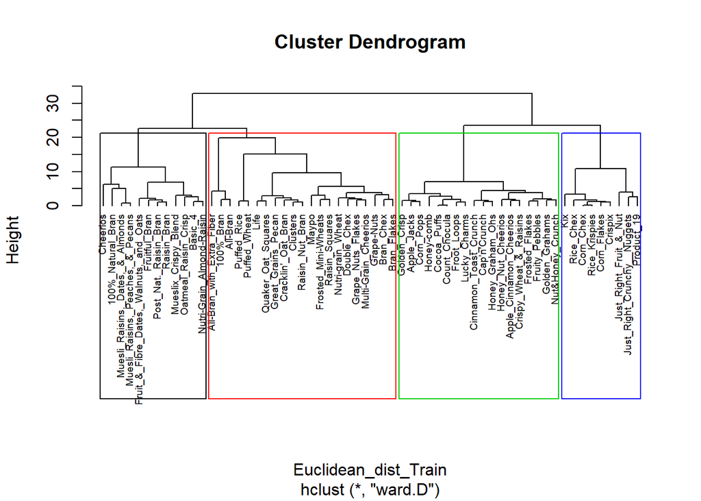

```r
Euclidean_dist_Train <- dist(Train_Data, method = "euclidean")
Dist_Ward_Train <- hclust(Euclidean_dist_Train, method = "ward.D")

plot(Dist_Ward_Train, cex = 0.6, hang = -2)
rect.hclust(Dist_Ward_Train, k = 4, border = 1:4)
```

```r
Cluster_group_Train <- cutree(Dist_Ward_Train, k = 4)
table(Cluster_group_Train)
```

```
## Cluster_group_Train
##  1  2  3  4
## 21 12 18  9
```

```r
Train_Data <- cbind.data.frame(Train_Data, Cluster_group_Train)
```

Here we are calculating the centriods for each cluster and storing them together so that we can calculate the distance between each data of test set and all centroids.

The cluster with minimum of its centroid and test set distance will be the cluster of the respective test set.

```r
Centroid_1 <- colMeans(Train_Data[Train_Data$Cluster_group_Train == "1",])
Centroid_2 <- colMeans(Train_Data[Train_Data$Cluster_group_Train == "2",])
Centroid_3 <- colMeans(Train_Data[Train_Data$Cluster_group_Train == "3",])
Centroid_4 <- colMeans(Train_Data[Train_Data$Cluster_group_Train == "4",])

Centroid <- rbind(Centroid_1, Centroid_2, Centroid_3, Centroid_4)

TestData_Centroid <- rowMins(distance(Test_Data, Centroid[,-13]))

Partition_Centroid <- c(Train_Data$Cluster_group_Train,TestData_Centroid)

clustered_Data<- cbind(clustered_Data,Partition_Centroid)
```

3. Assess how consistent the cluster assignments are compared to the assignments based on all the data.

```r
table(clustered_Data$Cluster_group == clustered_Data$Partition_Centroid)
```

```
##
## FALSE  TRUE
##    17    57
```

```r
table(clustered_Data$Cluster_group[61:74] == clustered_Data$Partition_Centroid[61:74])
```

```
##
## FALSE  TRUE
##     2    12
```

The table here represents comparision number of data from the previously calculated clustering and one with the partition data.

4.) The elementary public schools would like to choose a set of cereals to include in their daily cafeterias. Every day a different cereal is offered, but all cereals should support a healthy diet. For this goal, you are requested to find a cluster of “healthy cereals.” Should the data be normalized? If not, how should they be used in the cluster analysis?

Here we are calculating the centriods for the entire dataset.

```r
Centroid1 <- colMeans(clustered_Data[clustered_Data$Cluster_group == "1",])
Centroid2 <- colMeans(clustered_Data[clustered_Data$Cluster_group == "2",])
Centroid3 <- colMeans(clustered_Data[clustered_Data$Cluster_group == "3",])
Centroid4 <- colMeans(clustered_Data[clustered_Data$Cluster_group == "4",])

Centroid_all <- rbind(Centroid1, Centroid2, Centroid3, Centroid4)
View(Centroid_all)
```

The plot represents the average value of each nutrient contents based on entire dataset

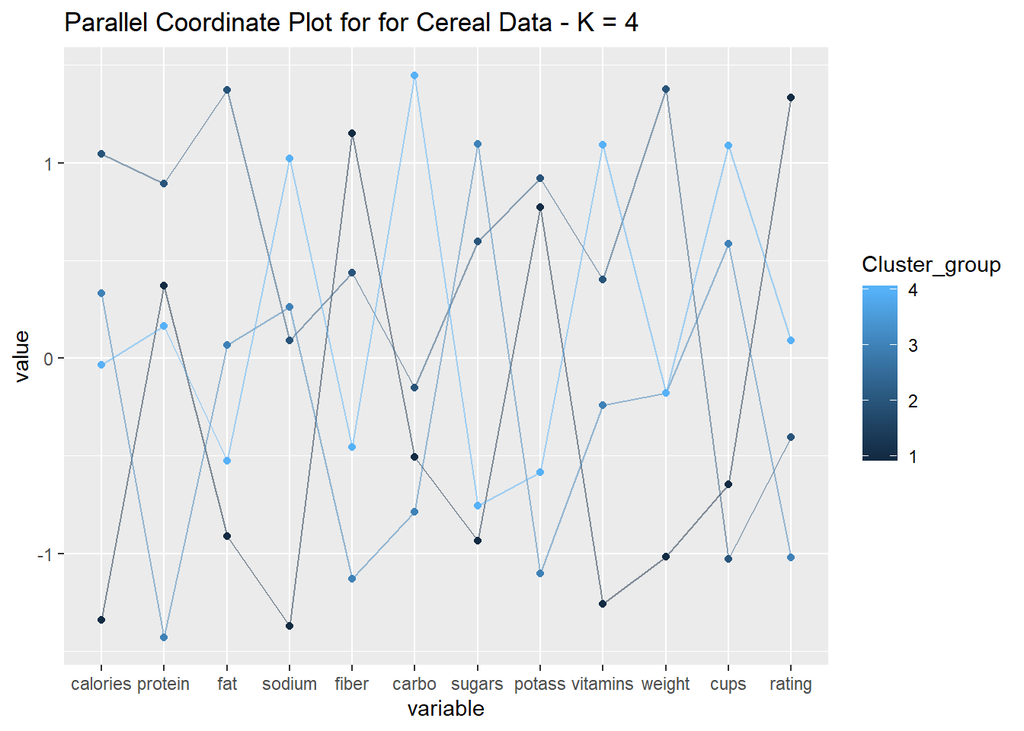

```r
ggparcoord(Centroid_all,
           columns = 1:12, groupColumn = 13,
           showPoints = TRUE,
           title = "Parallel Coordinate Plot for for Cereal Data - K = 4",
           alphaLines = 0.5
)
```

Also, by looking at the Parallel Coordinate Plot, Cluster 1 staisfies most the healthy cereals requirement as compared to the other clusters. The Calories, fat, sodium and sugar are lower than the remaining clusters, whereas fiber contents and the customer ratings are higher. Hence, the elementary public schools will probably like to choose cluster 1 cereals as ‘Healthy cereals’ to include in their daily cafeterias.

```r
Breakfast <- clustered_Data[clustered_Data$Cluster_group == '1',]

row.names(Breakfast)
```

```
##  [1] "100%_Bran"                 "All-Bran"
##  [3] "All-Bran_with_Extra_Fiber" "Frosted_Mini-Wheats"
##  [5] "Maypo"                     "Puffed_Rice"
##  [7] "Puffed_Wheat"              "Raisin_Squares"
##  [9] "Shredded_Wheat"            "Shredded_Wheat_'n'Bran"
## [11] "Shredded_Wheat_spoon_size" "Strawberry_Fruit_Wheats"
```

Hence, the above cereals should be included in the breakfast meal plan for the school.